# Lab2 R Notebook

## Setting working directory

```r
getwd()
```

```
[1] "/Volumes/Samsung_T3/Fall2017/Quant/Labs/rNotebook1/Lab2"
```

DATA: lowbwt

About the data: The goal of this study was to identify risk factors associated with giving birth to a low birth weight baby (weighing less than 2500 grams). Data were collected on 189 women, 59 of which had low birth weight babies and 130 of which had normal birth weight babies. Four variables which were thought to be of importance were age, weight of the subject at her last menstrual period, race, and the number of physician visits during the first trimester of pregnancy.

Low birth weight is an outcome that has been of concern to physicians for years. This is due to the fact that infant mortality rates and birth defect rates are very high for low birth weight babies. A woman’s behavior during pregnancy (including diet, smoking habits, and receiving prenatal care) can greatly alter the chances of carrying the baby to term and, consequently, of delivering a baby of normal birth weight. SOURCE: Hosmer and Lemeshow (2000) Applied Logistic Regression: Second Edition. These data are copyrighted by John Wiley & Sons Inc. and must be acknowledged and used accordingly. Data were collected at Baystate Medical Center, Springfield, Massachusetts during 1986.

# Graphs: Pie Chart & Bar Chart

Pie charts and bar charts are appropriate for nominal or ordinal variables with only a few values. To get charts for the variable race do the following. First, lets do a pie chart.

Show a frequency table for RACE

```r
table(lowbwt$RACE)
```

```
 1  2  3
96 26 67
```

```r
prop.table(table(lowbwt$RACE))
```

```
        1         2         3
0.5079365 0.1375661 0.3544974
```

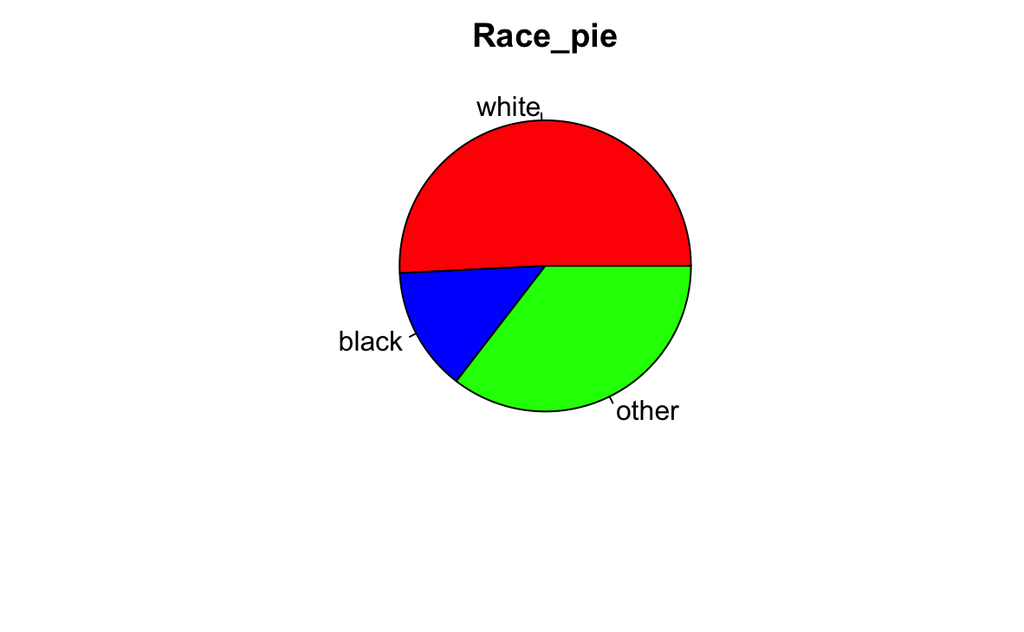

Here is how to do a bar chart.

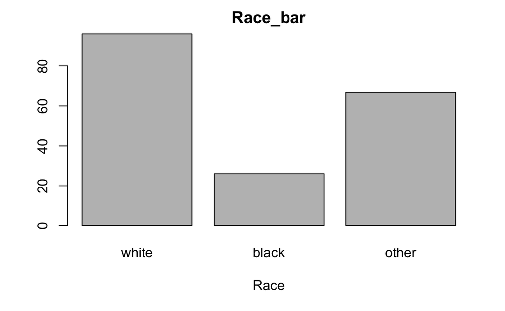

# Graphs: Histogram

Histograms are appropriate for interval-ratio variables with only a few values. Histograms can be obtained in the Explore function. To get summary statistics and a histogram for the variable age. Does this seem like a normal distribution? Where are ages concentrated in this dataset?

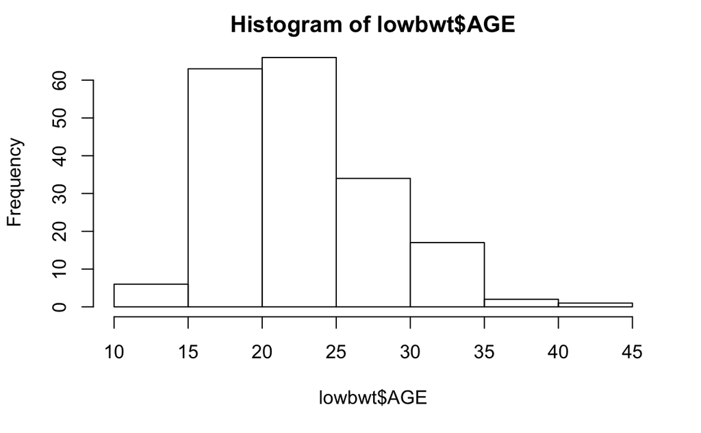

# Kernal density plots

Kernal density plots show the same informatoin as histograms but by using statistical smoothing approaches create a more generalizable perspective.

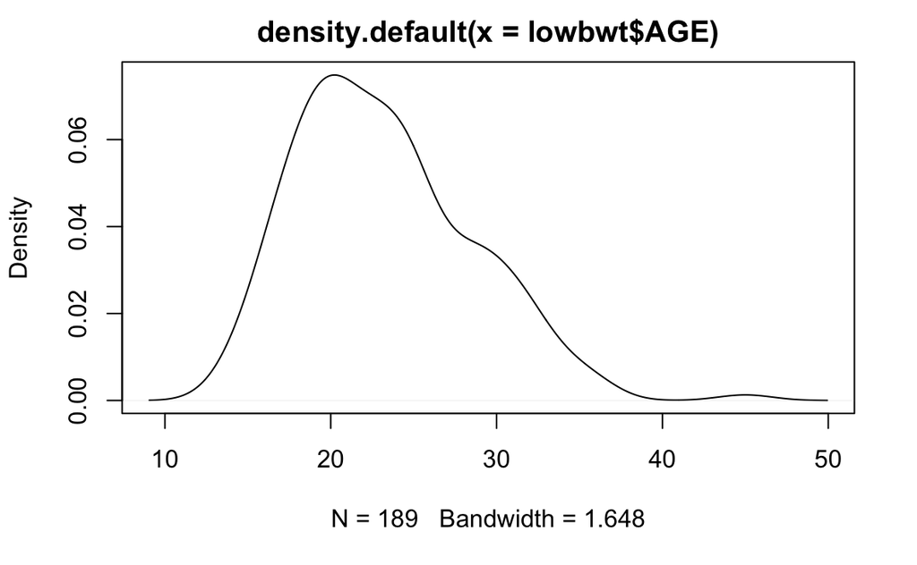

That is fine, but we can do better. First, you’ll need to install the ggplot package. This package is heavily used in applied work. ggplot comes with a whole data visualization “grammar”. We are just going to use it for the basics but you may want to learn more about it. Then you can apply the code. So, now lets use the ggplot package to get a nicer plot and lets overlay two plots on top of each other. Lets look at a plot of age based on the low birth weight dummy variable

```r
install.packages("ggplot2")
library(ggplot2)
```

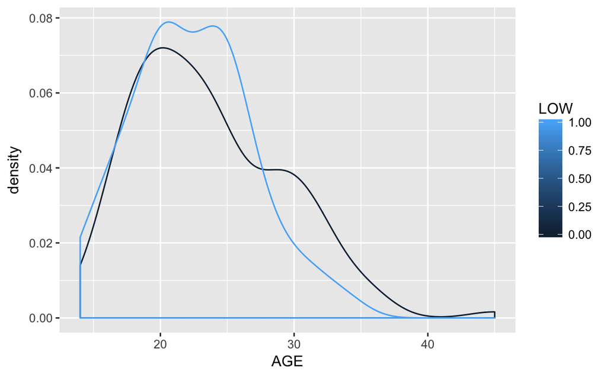

# Boxplots

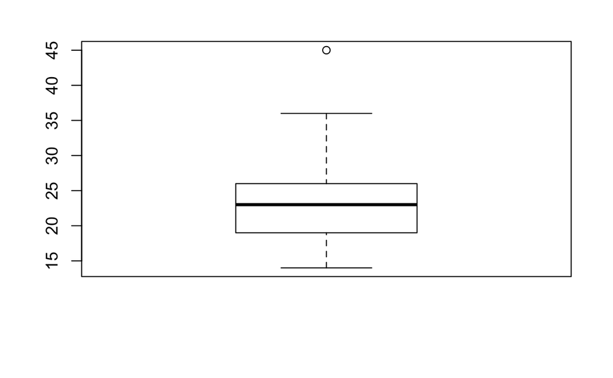

# Violin Plots

```r
 install.packages("vioplot")
 library(vioplot)
```

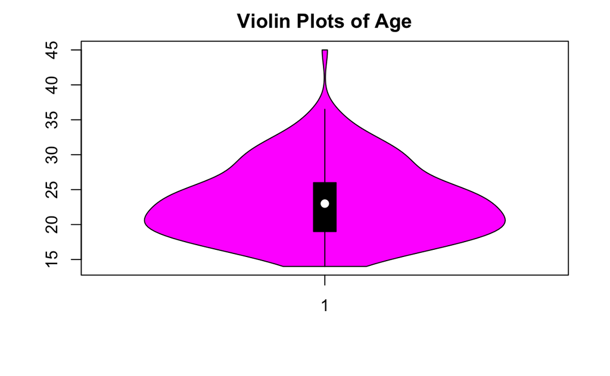

# Crosstabs

A crosstab displays the joint frequency distributions of two nominal or ordinal variables. Crosstabs can help show whether there is a relationship between two nominal or ordinal variables.

```r
table(lowbwt$HT, lowbwt$RACE)
```

```
     1  2  3
  0 91 23 63
  1  5  3  4
```

But this looks sort of ugly. It is also very hard to interpret because the column sizes vary. Let’s make a nicer and more useful table. first we need another package (the “gmodels” package)

```r
install.packages("gmodels")
library(gmodels)
```

```r
CrossTable(lowbwt$HT, lowbwt$RACE, expected=TRUE, format="SPSS")
```

```
Chi-squared approximation may be incorrect
```

```
   Cell Contents
|-------------------------|
|                   Count |
|         Expected Values |
| Chi-square contribution |
|             Row Percent |
|          Column Percent |
|           Total Percent |
|-------------------------|

Total Observations in Table:  189

             | lowbwt$RACE
   lowbwt$HT |        1  |        2  |        3  | Row Total |
-------------|-----------|-----------|-----------|-----------|
           0 |       91  |       23  |       63  |      177  |
             |   89.905  |   24.349  |   62.746  |           |
             |    0.013  |    0.075  |    0.001  |           |
             |   51.412% |   12.994% |   35.593% |   93.651% |
             |   94.792% |   88.462% |   94.030% |           |
             |   48.148% |   12.169% |   33.333% |           |
-------------|-----------|-----------|-----------|-----------|
           1 |        5  |        3  |        4  |       12  |
             |    6.095  |    1.651  |    4.254  |           |
             |    0.197  |    1.103  |    0.015  |           |
             |   41.667% |   25.000% |   33.333% |    6.349% |
             |    5.208% |   11.538% |    5.970% |           |
             |    2.646% |    1.587% |    2.116% |           |
-------------|-----------|-----------|-----------|-----------|
Column Total |       96  |       26  |       67  |      189  |
             |   50.794% |   13.757% |   35.450% |           |
-------------|-----------|-----------|-----------|-----------|


Statistics for All Table Factors


Pearson's Chi-squared test
------------------------------------------------------------
Chi^2 =  1.40381     d.f. =  2     p =  0.4956401



       Minimum expected frequency: 1.650794
Cells with Expected Frequency < 5: 2 of 6 (33.33333%)
```

We can also use bar charts to show the same information, like this

```r
install.packages("sjPlot")
```

[output not shown]

[output not shown]

```
* DONE (sjstats)
```

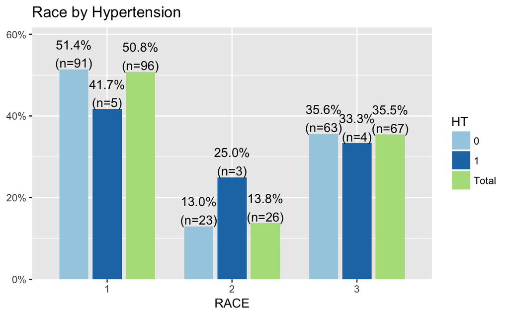

```r
library(sjPlot)
sjp.xtab(lowbwt$RACE,lowbwt$HT, title = "Race by Hypertension")
```

Assignment 2 Create a New R Notebook (*.NB) File > New File > R Notebook Name it “Assignment2.R Notebook” and save it in the Home folder.

Data frame for this assignment: lowbwt 1. List the level of measurement for each of the following variables:

1. LOW
2. SMOKE
3. BWT
2. Show a frequency table and an appropriate graph for the variable Smoking Status During Pregnancy.
3. Describe the distribution of Smoking Status During Pregnancy.
4. Show a frequency table and an appropriate graph for the variable Low Birth Weight.
5. Show summary statistics and an appropriate graph for Birth Weight in Grams(BWT).
6. Describe the distribution of Birth Weight in Grams(BWT).
7. Create a kernal density plot to describe the distribution of Birth Weight in Grams (BWT) for those who suffer from uterine irritability and then for those who do not. Try to use the code to overlay these plots on top of each other. Describe the pattern. The uterine irritablity variable is called UI. Remember you need install and library packages ggplot2.packages before creating this kernal density plot.
8. Show a crosstab of Low Birth Weight BY Smoking Status During Pregnancy. Be sure to show and interpret the percentages (interpreting the column percenages is suffecient)
9. Does there appear to be a relationship between Low Birth Weight and Smoking Status During Pregnancy? Uterine Irritability? Explain.

Submit to Canvas: your notebook. The notebook should include your code, the output and (importantly!) your interpretation of the findings.

Advanced material

# Here’s an example of a density plot overlay which also shows the mean of two groups. Here I use the drug treatment dataset which we worked with last time. The example looks at the beck depression scale by site. Study participants were not randomized by site. In this example we show the mean on the plot itself.

```r
install.packages("plyr")
library(plyr)
```